# Spotcap Data Science Case Study

Roshan Kumar Bhuyan

# 1 Goal

> The goal of this task is to conduct an *Exploratory Data Analysis (EDA)* and model a credit portfolio.

# 2 Universal Libraries

> Theese libraries are used throught the code. Libraries specific to the line of code are defined with the code.

```r
library(tidyverse)
library(caret)
library(magrittr)
```

# 3 Data Import

> The Dataset contains 14 labels  
> **Status**: The Credit Status of the person  
> **Seniority**: Job Seniority  
> **Home**: Type of Home Ownership  
> **Time**: Time requested for Repayment of Loan  
> **Age**: Age  
> **Maritial Status**: Maritial Status  
> **Records**: If the person has a financial Record  
> **Job**: The Type of Job  
> **Expense**: Amoubt of Expense  
> **Income**: Amount of Income  
> **Assets**: Price of Assets owned  
> **Debt**: Amount of debt held  
> **Amount**: The amount requested in Loan  
> **Price**: The cost of the product

```r
library(readxl)
mydata <- read_excel("Spotcap Data Science Case Study.xlsx", sheet=1)
```

# 4 Data Wrangling

> This step introduces NA’s into the dataframe .

```r
mydata[mydata==99999999]<-  NA
```

> Introducing addition labels for better visualizations.  
> **Savings** = Income - Expenses,  
> **Net_worth** = Assets - Debt,  
> **Down_pay** = Price - Amount,  
> **Loan_perc** = Percentage of the cost requested as loan.

```r
mydata2 <- mydata %>%  mutate(Savings = Income-Expenses, Net_worth = Assets-Debt,
                              Down_pay=Price-Amount,loan_perc= Amount*100/Price)
mydata2 <- mydata2[ c(1:8,10,9,15,11,12,16,13,14,17,18)] #Rearranging the Columns
```

> Changing numerals into factors and adding NA’s to unavailable values.

```r
mydata2$Status <- factor(mydata2$Status, levels = c(1,2), labels = c("Good", "Bad"))
mydata2$Home <- factor(mydata2$Home, levels = c(1,2,3,4,5,6),
                       labels = c("Rent", "Owner","Private", "Ignore", "Parents", "Other"))
mydata2$Marital <- factor(mydata2$Marital, levels = c(1,2,3,4,5),
                         labels =  c("Single", "Married", "Widow", "Separated", "Divorced"))
mydata2$Records <-  factor(mydata2$Records, levels = c(1,2),
                           labels =  c("Not_Avaliable", "Avaliable"))
mydata2$Job <- factor(mydata2$Job, levels = c(1,2,3,4),
                     labels = c("Fixed", "Partime", "Freelance", "Others"))
summary(mydata2)
```

```
##   Status       Seniority           Home           Time
##  Good:3200   Min.   : 0.000   Rent   : 973   Min.   : 6.00
##  Bad :1254   1st Qu.: 2.000   Owner  :2107   1st Qu.:36.00
##  NA's:   1   Median : 5.000   Private: 247   Median :48.00
##              Mean   : 7.987   Ignore :  20   Mean   :46.44
##              3rd Qu.:12.000   Parents: 783   3rd Qu.:60.00
##              Max.   :48.000   Other  : 319   Max.   :72.00
##                               NA's   :   6
##       Age             Marital              Records            Job
##  Min.   :18.00   Single   : 978   Not_Avaliable:3682   Fixed    :2806
##  1st Qu.:28.00   Married  :3241   Avaliable    : 773   Partime  : 452
##  Median :36.00   Widow    :  67                        Freelance:1024
##  Mean   :37.08   Separated: 130                        Others   : 171
##  3rd Qu.:45.00   Divorced :  38                        NA's     :   2
##  Max.   :68.00   NA's     :   1
##
##      Income         Expenses         Savings            Assets
##  Min.   :  0.0   Min.   : 35.00   Min.   :-165.00   Min.   :     0
##  1st Qu.: 80.0   1st Qu.: 35.00   1st Qu.:  30.00   1st Qu.:     0
##  Median :120.0   Median : 51.00   Median :  65.00   Median :  3000
##  Mean   :130.6   Mean   : 55.57   Mean   :  75.02   Mean   :  5403
##  3rd Qu.:165.0   3rd Qu.: 72.00   3rd Qu.: 108.00   3rd Qu.:  6000
##  Max.   :959.0   Max.   :180.00   Max.   : 824.00   Max.   :300000
##  NA's   :34                       NA's   :34        NA's   :47
##       Debt           Net_worth          Amount         Price
##  Min.   :    0.0   Min.   : -4000   Min.   : 100   Min.   :  105
##  1st Qu.:    0.0   1st Qu.:     0   1st Qu.: 700   1st Qu.: 1118
##  Median :    0.0   Median :  3000   Median :1000   Median : 1400
##  Mean   :  342.9   Mean   :  5058   Mean   :1039   Mean   : 1463
##  3rd Qu.:    0.0   3rd Qu.:  5471   3rd Qu.:1300   3rd Qu.: 1692
##  Max.   :30000.0   Max.   :300000   Max.   :5000   Max.   :11140
##  NA's   :18        NA's   :47
##     Down_pay         loan_perc
##  Min.   :    0.0   Min.   :  6.702
##  1st Qu.:  142.0   1st Qu.: 60.040
##  Median :  300.0   Median : 77.101
##  Mean   :  423.9   Mean   : 72.610
##  3rd Qu.:  594.0   3rd Qu.: 88.422
##  Max.   :10140.0   Max.   :100.000
##
```

# 5 Checking the NA

> This creates a subset of the main data frame . If there are NA’s in any row, its subsetted here

```r
Na_DF <- mydata2[rowSums(is.na(mydata2)) > 0,]
```

> Compare original with subset using visualization  
> It is observed that the most NA’s occour with freelancers who do not show an income.  
> There exist 80 Rows with NA’s which is 1.7% of the dataset.  
> The Subset needs to be compared to the original dataset.

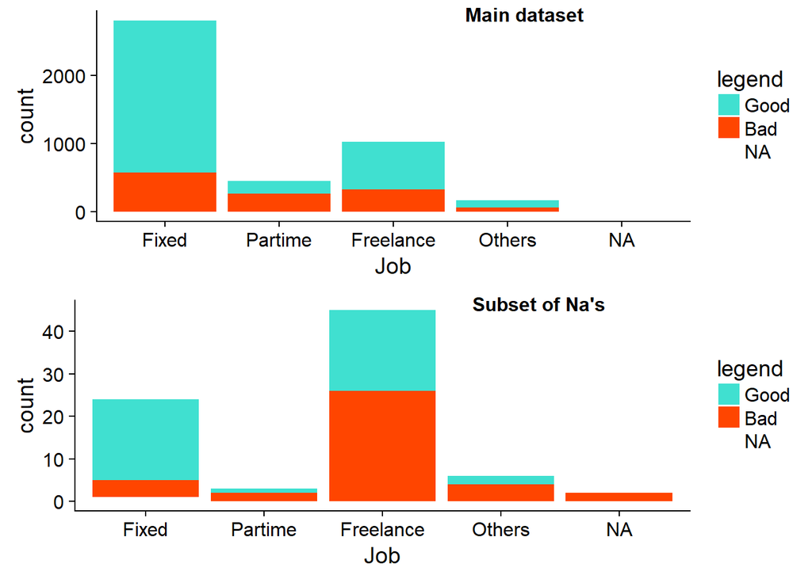

```r
a= ggplot(data = mydata2, aes(x =Job, y = , fill = Status)) + geom_bar() +
  scale_fill_manual("legend", values = c("Good" = "turquoise", "Bad" = "orangered1","NA"= "grey"))
b= ggplot(data = Na_DF, aes(x =Job, y = , fill = Status)) + geom_bar() +
  scale_fill_manual("legend", values = c("Good" = "turquoise", "Bad" = "orangered1","NA"= "grey"))
library(cowplot)
plot_grid(a, b, labels = c('Main dataset', "Subset of Na's"),ncol = 1,align = 'V',label_size = 12,
          label_x = 0.5, label_y = 1, rel_widths = c(1.8, 1.8))
```

```r
mydata3 <- mydata2[complete.cases(mydata2),]
```

# 6 Visualization

> Looking for patterns in the data before applying machine learning.

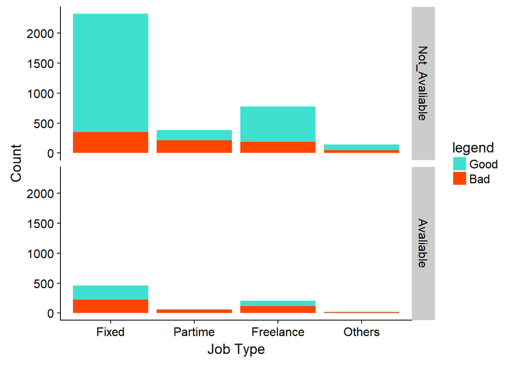

```r
#Comparing Job type with the Credit Status and avaliability of past records.
ggplot(data = mydata3, aes(x =Job, y = , fill = Status)) + geom_bar() +
  facet_grid(Records ~ .) + xlab("Job Type") + ylab("Count") +
  scale_fill_manual("legend", values = c("Good" = "turquoise", "Bad" = "orangered1"))
```

>

> People with no past records tend to have a good status as compared to the people with records. There exists a bias as having no past records might be helping getting a good credit status.

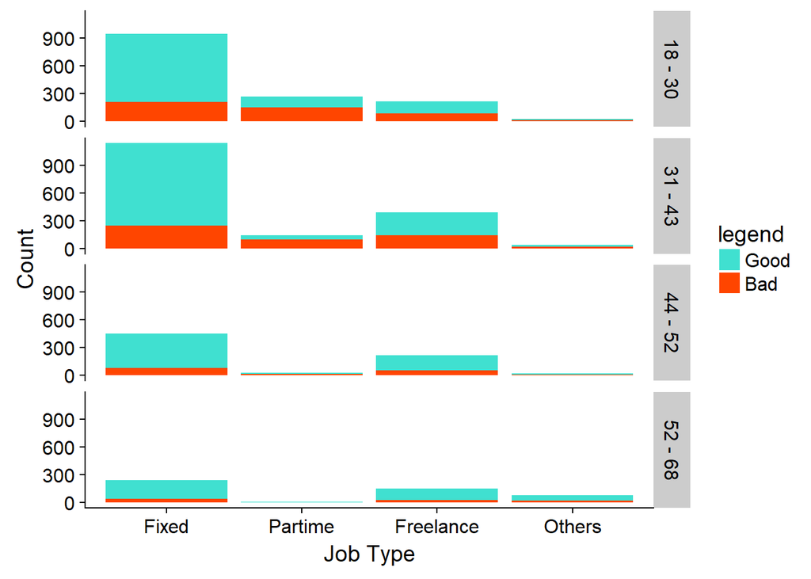

```r
# Comapring credit status with respect to age.
mydata4 <- mydata3
# discretization of age into 4 groups for plotting
mydata4$Age <- cut(mydata4$Age, breaks=c(17, 30, 43, 52 ,Inf),
                   labels=c("18 - 30", "31 - 43", "44 - 52", "52 - 68"))
ggplot(data = mydata4, aes(x =Job, y = , fill = Status)) + geom_bar() + facet_grid(Age ~ .) +
  xlab("Job Type") + ylab("Count") +
  scale_fill_manual("legend", values = c("Good" = "turquoise", "Bad" = "orangered1"))
```

>

> The credit statuses are fairly similarly distributed across different age groups hence there are no patterns to be seen .

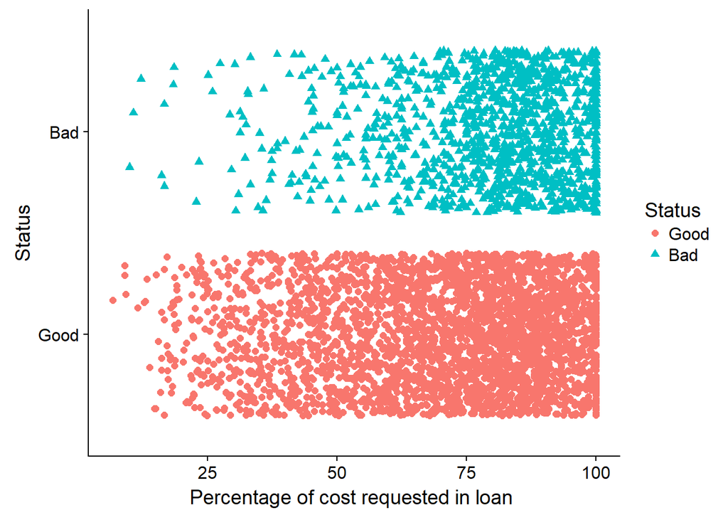

```r
# checking the percentage of cost demanded as loan with respect to status
ggplot(data=mydata3, aes(x=loan_perc, y=Status))+
  geom_jitter(size=2, na.rm=TRUE, aes(color=Status, shape=Status)) +
  xlab("Percentage of cost requested in loan ") +ylab("Status")
```

>

> It is observed that people with a bad credit status tend to pay less in downpayment.

# 7 Prepraring data for Machine Learning to predict Credit Status

> Creating a 70% - 30% partition for the Train and the Test set using the Caret library

```r
set.seed(345)
indexes <- createDataPartition(y=mydata3$Status, times=1,p=0.7,list=FALSE)
trainSet<- mydata3[indexes,]
testSet <- mydata3[-indexes,]
```

# 8 Applying the Random Forest Algorithm

> Training the algorithm

```r
set.seed(2334)
ctrl <- trainControl(method="repeatedcv",number=2,repeats = 2)
start.time <- Sys.time()  #To note the time taken to train an algorithm
Rf_tune <- train(Status~., data = trainSet, method= "rf",preProcess = c( "center","scale"),
                 trControl = ctrl, tuneLength = 8)
end.time <- Sys.time()
saveRDS(Rf_tune, file = "Rf_tune") # Saving the model
time.taken <- end.time - start.time
print(time.taken)
```

```
## Time difference of 1.249256 mins
```

```r
Rf_tune
```

```
## Random Forest
##
## 3064 samples
##   17 predictor
##    2 classes: 'Good', 'Bad'
##
## Pre-processing: centered (26), scaled (26)
## Resampling: Cross-Validated (2 fold, repeated 2 times)
## Summary of sample sizes: 1532, 1532, 1532, 1532
## Resampling results across tuning parameters:
##
##   mtry  Accuracy   Kappa
##    2    0.7863903  0.3649846
##    5    0.7901436  0.4252689
##    8    0.7880222  0.4289104
##   12    0.7870431  0.4320319
##   15    0.7847585  0.4277555
##   19    0.7832898  0.4244165
##   22    0.7862272  0.4324222
##   26    0.7832898  0.4243350
##
## Accuracy was used to select the optimal model using the largest value.
## The final value used for the model was mtry = 5.
```

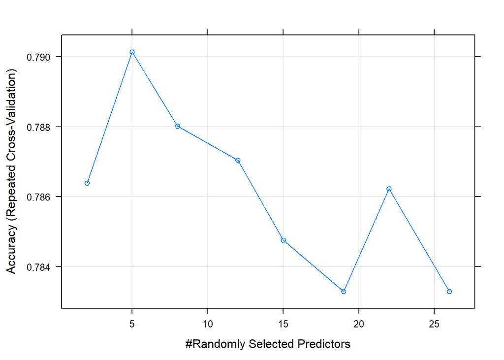

```r
#Rf_tune <- readRDS("Rf_tune") #used to import pretrained model
plot(Rf_tune)
```

> Testing the algorithm

```r
Rf_test = predict(Rf_tune, newdata=testSet,metric= accuracy)
postResample(Rf_test, testSet$Status)
```

```
##  Accuracy     Kappa
## 0.7948131 0.4448037
```

```r
confusionMatrix(data = Rf_test, testSet$Status)
```

```
## Confusion Matrix and Statistics
##
##           Reference
## Prediction Good Bad
##       Good  859 181
##       Bad    88 183
##
##                Accuracy : 0.7948
##                  95% CI : (0.7719, 0.8164)
##     No Information Rate : 0.7223
##     P-Value [Acc > NIR] : 9.596e-10
##
##                   Kappa : 0.4448
##  Mcnemar's Test P-Value : 2.031e-08
##
##             Sensitivity : 0.9071
##             Specificity : 0.5027
##          Pos Pred Value : 0.8260
##          Neg Pred Value : 0.6753
##              Prevalence : 0.7223
##          Detection Rate : 0.6552
##    Detection Prevalence : 0.7933
##       Balanced Accuracy : 0.7049
##
##        'Positive' Class : Good
##
```

# 8 Applying the Support Vector Machine Algorithm

> Training the algorithm

```r
set.seed(238)
ctrl <- trainControl(method="repeatedcv",number=2,repeats = 2)
start.time <- Sys.time()
Svm_tune <- train(Status~., data = trainSet, method= "svmLinear",preProcess = c( "center","scale"),
                 trControl = ctrl, tuneLength = 8)
end.time <- Sys.time()
saveRDS(Svm_tune, file = "Svm_tune")
time.taken <- end.time - start.time
print(time.taken)
```

```
## Time difference of 3.199067 secs
```

```r
Svm_tune
```

```
## Support Vector Machines with Linear Kernel
##
## 3064 samples
##   17 predictor
##    2 classes: 'Good', 'Bad'
##
## Pre-processing: centered (26), scaled (26)
## Resampling: Cross-Validated (2 fold, repeated 2 times)
## Summary of sample sizes: 1532, 1532, 1532, 1532
## Resampling results:
##
##   Accuracy   Kappa
##   0.7960183  0.4468644
##
## Tuning parameter 'C' was held constant at a value of 1
```

> Testing the algorithm

```r
Svm_test = predict(Svm_tune, newdata=testSet,metric= accuracy)
postResample(Svm_test, testSet$Status)
```

```
##  Accuracy     Kappa
## 0.7963387 0.4479182
```

```r
confusionMatrix(data = Svm_test, testSet$Status)
```

```
## Confusion Matrix and Statistics
##
##           Reference
## Prediction Good Bad
##       Good  861 181
##       Bad    86 183
##
##                Accuracy : 0.7963
##                  95% CI : (0.7735, 0.8178)
##     No Information Rate : 0.7223
##     P-Value [Acc > NIR] : 4.223e-10
##
##                   Kappa : 0.4479
##  Mcnemar's Test P-Value : 8.783e-09
##
##             Sensitivity : 0.9092
##             Specificity : 0.5027
##          Pos Pred Value : 0.8263
##          Neg Pred Value : 0.6803
##              Prevalence : 0.7223
##          Detection Rate : 0.6568
##    Detection Prevalence : 0.7948
##       Balanced Accuracy : 0.7060
##
##        'Positive' Class : Good
##
```

# 9 Applying the KNN Algorithm

> Training the algorithm

```r
set.seed(232)
ctrl <- trainControl(method = "repeatedcv", number = 2, repeats = 1)
start.time <- Sys.time()
Knn_tune <- train(Status~., data = trainSet, method= "knn",preProcess = c( "center","scale"),
                  trControl = ctrl,tuneLength = 8)
end.time <- Sys.time()
time.taken <- end.time - start.time
print(time.taken)
```

```
## Time difference of 2.775847 secs
```

```r
saveRDS(Knn_tune, file = "Knn_tune")
Knn_tune
```

```
## k-Nearest Neighbors
##
## 3064 samples
##   17 predictor
##    2 classes: 'Good', 'Bad'
##
## Pre-processing: centered (26), scaled (26)
## Resampling: Cross-Validated (2 fold, repeated 1 times)
## Summary of sample sizes: 1532, 1532
## Resampling results across tuning parameters:
##
##   k   Accuracy   Kappa
##    5  0.7535901  0.3288287
##    7  0.7646867  0.3418078
##    9  0.7682768  0.3464336
##   11  0.7659922  0.3315207
##   13  0.7646867  0.3215986
##   15  0.7633812  0.3073870
##   17  0.7624021  0.2965496
##   19  0.7627285  0.2911199
##
## Accuracy was used to select the optimal model using the largest value.
## The final value used for the model was k = 9.
```

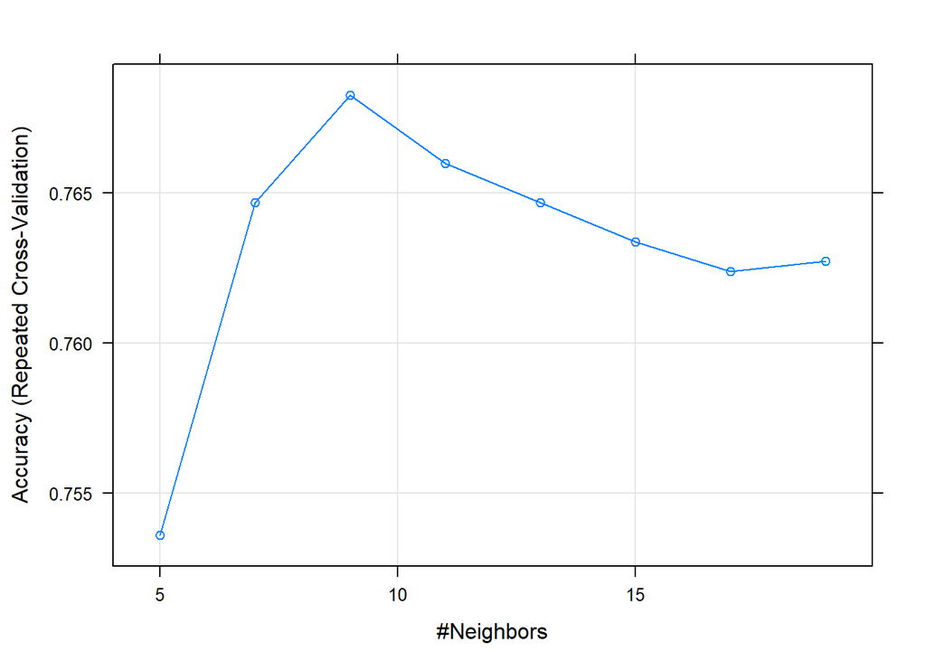

```r
plot(Knn_tune)
```

> Testing the algorithm

```r
Knn_test = predict(Knn_tune, newdata=testSet,metric= accuracy)
postResample(Knn_test, testSet$Status)
```

```
##  Accuracy     Kappa
## 0.7711670 0.3566107
```

```r
confusionMatrix(data = Knn_test, testSet$Status)
```

```
## Confusion Matrix and Statistics
##
##           Reference
## Prediction Good Bad
##       Good  864 217
##       Bad    83 147
##
##                Accuracy : 0.7712
##                  95% CI : (0.7475, 0.7937)
##     No Information Rate : 0.7223
##     P-Value [Acc > NIR] : 3.319e-05
##
##                   Kappa : 0.3566
##  Mcnemar's Test P-Value : 1.606e-14
##
##             Sensitivity : 0.9124
##             Specificity : 0.4038
##          Pos Pred Value : 0.7993
##          Neg Pred Value : 0.6391
##              Prevalence : 0.7223
##          Detection Rate : 0.6590
##    Detection Prevalence : 0.8246
##       Balanced Accuracy : 0.6581
##
##        'Positive' Class : Good
##
```

# 10 Function to remove outliers.

> This is a function that removes outliers.  
> This function uses the Tukey’s method which use interquartile (IQR) range approach and was written by Dr. [Klodian Dhana](https://datascienceplus.com/identify-describe-plot-and-removing-the-outliers-from-the-dataset/).  
> This original function replaces outliers with NA but has been modified to replace Outliers with Median.

```r
outlierKD <- function(dt, var) {
  #define variables
  var_name <- eval(substitute(var),eval(dt))
  tot <- sum(!is.na(var_name))
  m1 <- median(var_name, na.rm = T)
  outlier <- boxplot.stats(var_name)$out
  mo <- median(outlier)

  #create 2x2 canvas
  par(mfrow=c(2, 2), oma=c(0,0,3,0))
  boxplot(var_name, main="With outliers")
  hist(var_name, main="With outliers", xlab=NA, ylab=NA)

  # If value is an outlier introduce median
  # If not, do nothing
  var_name <- ifelse(var_name %in% outlier, m1, var_name)
  m2 <- median(var_name, na.rm = T)
  na <- length(outlier)
  boxplot(var_name, main="Without outliers")
  hist(var_name, main="Without outliers", xlab=NA, ylab=NA)
  title("Outlier Check for var", outer=TRUE)

  #print messages
  message("Outliers identified: ", na, " from ", tot, " observations")
  message("Proportion (%) of outliers: ", na / tot*100)
  message("Median of the outliers: ", mo)
  message("Median without removing outliers: ", m1)
  message("Median if we remove outliers: ", m2)

  dt[as.character(substitute(var))] <- invisible(var_name)
  assign(as.character(as.list(match.call())$dt), dt, envir = .GlobalEnv)
  message("Outliers successfully removed", "\n")
  par(mfrow= c(1,1),oma=c(0,0,0,0))
  return(invisible(dt))
}
```

# 11 Remove outliers to and apply SVM to check if accuracy is improved

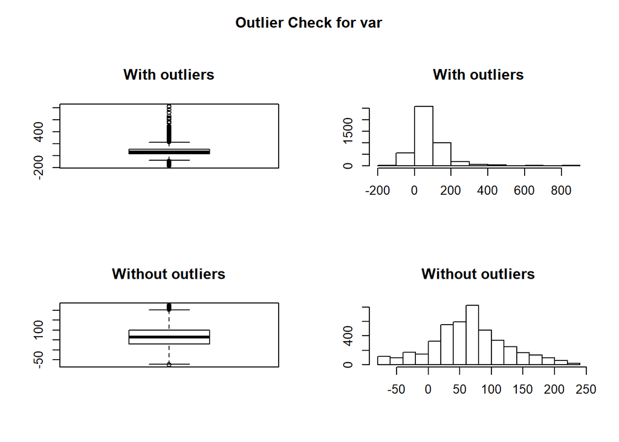

```r
mydata5 <- mydata3  # creating a copy of the dataset
outlierKD(mydata5,Savings) #remove outliers from Savings
```

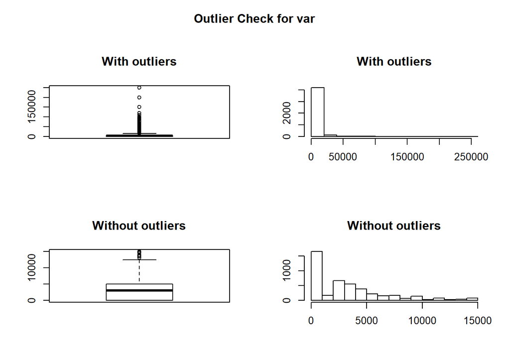

```r
outlierKD(mydata5,Assets)  #remove outliers from Assets
```

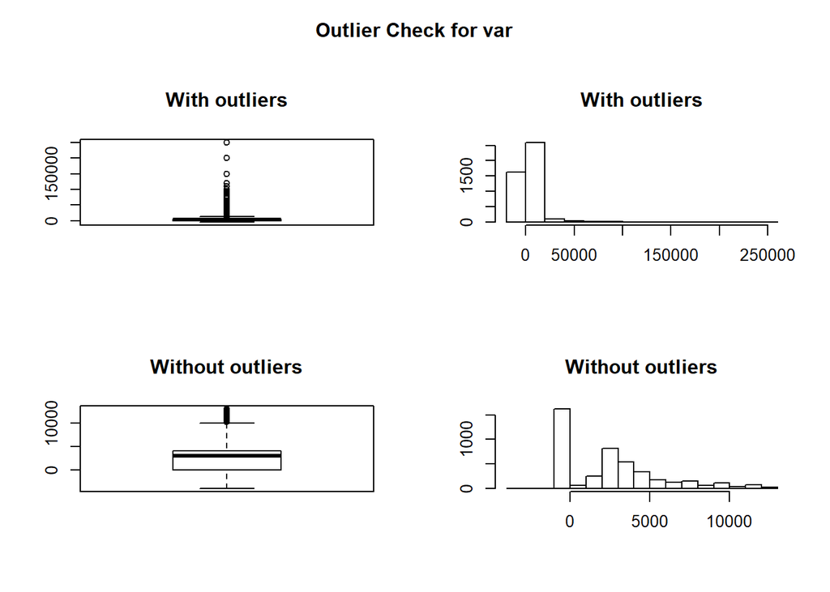

```r
outlierKD(mydata5,Net_worth) #remove outliers from Net_worth
```

> Creating a new partition

```r
set.seed(345)
indexes <- createDataPartition(y=mydata5$Status, times=1,p=0.7,list=FALSE)
trainSet1<- mydata5[indexes,]
testSet1 <- mydata5[-indexes,]
```

> Training the algorithm

```r
set.seed(238)
ctrl <- trainControl(method="repeatedcv",number=2,repeats = 1)
start.time <- Sys.time()
Svm_tune1 <- train(Status~., data = trainSet1, method= "svmLinear",preProcess = c( "center","scale"),
                 trControl = ctrl, tuneLength = 8)
end.time <- Sys.time()
saveRDS(Svm_tune1, file = "Svm_tune1")
time.taken <- end.time - start.time
print(time.taken)
```

```
## Time difference of 2.048714 secs
```

```r
Svm_tune1
```

```
## Support Vector Machines with Linear Kernel
##
## 3064 samples
##   17 predictor
##    2 classes: 'Good', 'Bad'
##
## Pre-processing: centered (26), scaled (26)
## Resampling: Cross-Validated (2 fold, repeated 1 times)
## Summary of sample sizes: 1532, 1532
## Resampling results:
##
##   Accuracy   Kappa
##   0.7973238  0.4544416
##
## Tuning parameter 'C' was held constant at a value of 1
```

> Testing the algorithm

```r
Svm_test1 = predict(Svm_tune1, newdata=testSet1,metric= accuracy)
postResample(Svm_test1, testSet1$Status)
```

```
##  Accuracy     Kappa
## 0.8016781 0.4579061
```

```r
confusionMatrix(data = Svm_test1, testSet$Status)
```

```
## Confusion Matrix and Statistics
##
##           Reference
## Prediction Good Bad
##       Good  869 182
##       Bad    78 182
##
##                Accuracy : 0.8017
##                  95% CI : (0.779, 0.8229)
##     No Information Rate : 0.7223
##     P-Value [Acc > NIR] : 2.065e-11
##
##                   Kappa : 0.4579
##  Mcnemar's Test P-Value : 1.683e-10
##
##             Sensitivity : 0.9176
##             Specificity : 0.5000
##          Pos Pred Value : 0.8268
##          Neg Pred Value : 0.7000
##              Prevalence : 0.7223
##          Detection Rate : 0.6629
##    Detection Prevalence : 0.8017
##       Balanced Accuracy : 0.7088
##
##        'Positive' Class : Good
##
```

# 12 Applying Recursive Feature Evaluation

> This helps us find the top labels applied in the predictons

```r
my_control <- rfeControl(functions = rfFuncs, method = "repeatedcv",
                         repeats = 3, verbose = FALSE)
results <- rfe(mydata4[,2:18], mydata4$Status, rfeControl=my_control)
print(results)
```

```
##
## Recursive feature selection
##
## Outer resampling method: Cross-Validated (10 fold, repeated 3 times)
##
## Resampling performance over subset size:
##
##  Variables Accuracy  Kappa AccuracySD KappaSD Selected
##          4   0.7704 0.3743    0.01815 0.05236
##          8   0.7910 0.4398    0.01746 0.04902
##         16   0.7947 0.4510    0.01839 0.05205        *
##         17   0.7925 0.4442    0.01498 0.04324
##
## The top 5 variables (out of 16):
##    Records, Job, Savings, Seniority, Income
```

```r
# list the chosen features
predictors(results)
```

```
##  [1] "Records"   "Job"       "Savings"   "Seniority" "Income"
##  [6] "loan_perc" "Amount"    "Net_worth" "Down_pay"  "Home"
## [11] "Assets"    "Price"     "Time"      "Expenses"  "Age"
## [16] "Marital"
```

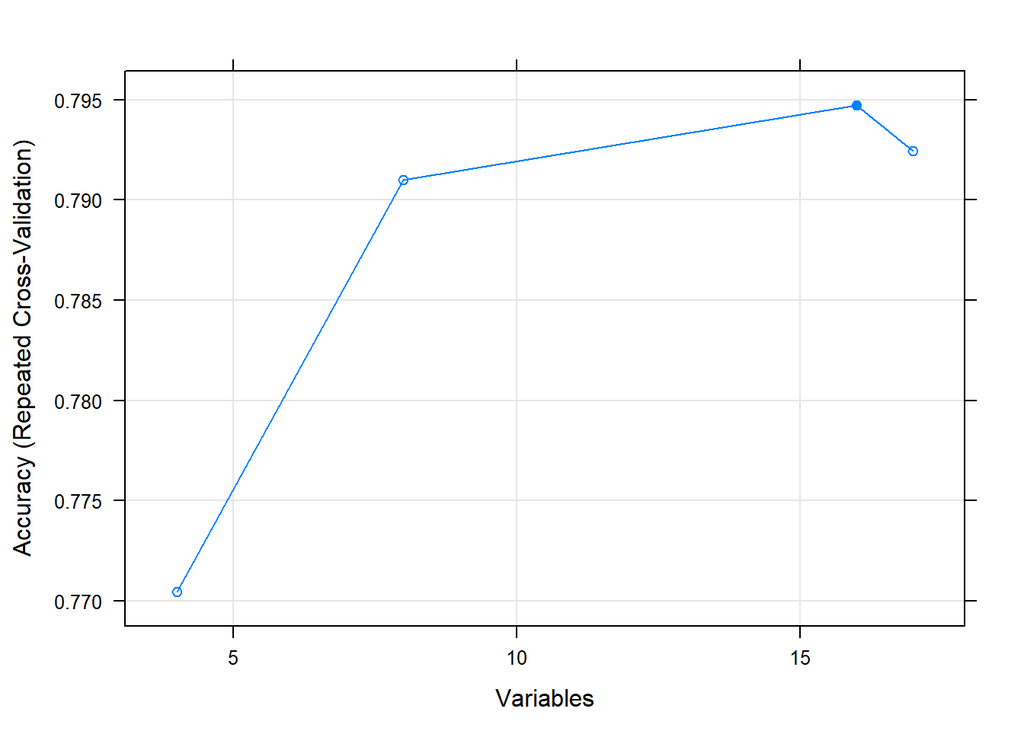

```r
# plot the results
plot(results, type=c("g", "o"))
```

# 13 Conclusion